# roahd Package: Robust Analysis of High Dimensional Data

# Robust statistics

In order to provide a center-outward and a down-upward/up-downward order of data, the Band Depth (BD) and Modified Band Depth (MBD) are implemented both for functional and multivariate functional data. Let us recall the empirical version of Band Depth for functional data, as introduced in (López-Pintado and Romo 2009) and in (López-Pintado and Romo 2011). Given a stochastic process $X$ taking values on the space $\mathcal{C}(I)$ of real continuous functions on the compact interval $I$, the empirical version of the band depth of order $J \ge 2$ for a function $f \in \mathcal{C}(I)$ is
$$\text{BD}^{J}_X( f ) = \sum_{j = 1}^{J} {N
\choose j}^{-1} \sum_{i_1 < i_2 < \ldots, < i_j }
\mathbb{I}\left\{ G(f) \subset B(f_{i_1},...,f_{i_j}) \right\},
\label{eq:band_depth_definition} (\#eq:band-depth-definition)$$
where the subset of the plane $G(f) = \{(t,f(t)): t \in I\}$ is the graph of the function $f$. $B(f_{1},f_{2},...,f_{j})$ is the band in $\mathbb{R}^2$ delimited by $f_{1},f_{2},...,f_{j}$, realizations of independent copies of the stochastic process $X$ (i.e. the functional dataset), and it is defined as:
$$B(f_{1},f_{2},...,f_{j})=\{(t,y(t)): t\in I,
\min_{r = 1,...,j} f_r(t) \leq y(t) \leq \max_{r = 1,...,j}
f_r(t)\}.$$
To overcome the problem of heavy ties due to the presence of the indicator function, (López-Pintado and Romo 2009) proposed the Modified Band Depth, where the time interval that $f$ spends in the random band is weighted over $I$. The empirical version of the MBD is:
$$\text{MBD}^{J}_X( f ) =
\sum_{j=2}^J \binom{N}{j}^{-1} \sum_{1 \leq i_1 < i_2 < \cdots
< i_j \leq n} \tilde{\lambda}\{E(f; f_{i_1},...,f_{i_j})\},
\label{MB:def:univ} (\#eq:MBdefuniv)$$
where $E(f) := E(f; f_{i_1},...,f_{i_j})$=$\{t\in I, \min_{r = i_1,...,i_j} f_{r}(t) \leq f(t) \leq \max_{r = i_1,...,i_j} f_{r}(t)\}$ and $\tilde{\lambda}(g) = \lambda(E(g))/\lambda(I)$ with $\lambda$ the Lebesgue measure on $I$. In (López-Pintado and Romo 2009), the authors state that while the choice of $J$ clearly increases the magnitude of depth, it does not affect the induced ordering and therefore the ranks. This was supported by a simulation study in (N. Tarabelloni et al. 2015). To reduce the computational effort we set $J=2$. Given a set of curves $(f,f_1,...f_N),$ the MBD of $f$, that we will denote by $MBD_{\{f_1,...,f_N\}}(f)$, measures the proportion of time interval $I$ where the graph of $f$ belongs to the envelopes of all the possible couples $(f_{i_1},f_{i_2})$, $i_1<i_2 = 1, \ldots, N$.

```r
    MBD(fD)
    [1] 0.48503510 0.46228408 0.51505469 0.31594122 0.37595102
    [6] 0.49060245 0.35306449 0.40934204 0.47676898 0.37799510
    [11] 0.22585633 0.45465633 0.49204245 0.34556571 0.14763429
    [16] 0.27375020 0.42478041 0.51758041 0.07788571 0.49579265
    ...
```

Another interesting down-upward/up-downward order of data can be built on top of Epigraph Index (EI) and Hypograph Index (HI) or of their corresponding Modified versions (MEI and MHI). We recall the definition of EI (HI) for univariate functional data as introduced in (López-Pintado and Romo 2011). Given a stochastic process $X$ taking values on the space $\mathcal{C}(I)$ the empirical version of the Epigraph (Hypograph) Index of a function $f \in \mathcal{C}(I)$ are:
$$EI_{X}(f) =
\frac{1}{N}\sum_{i=1}^N \mathbb{I}\left\{f_i(t) \geq f(t),\quad \forall
t \in I\right\},
\label{EI:def:univ} (\#eq:EIdefuniv)$$

$$HI_{X}(f) = \frac{1}{N}\sum_{i=1}^N
\mathbb{I}\left\{f_i(t) \leq f(t),\quad \forall t \in I\right\},
\label{HI:def:univ} (\#eq:HIdefuniv)$$
where $f_{1},f_{2},...,f_{N}$ are realizations of independent copies of the stochastic process $X$ (i.e. the functional dataset). As before, to overcome the problem of heavy ties it is more suitable to use the modified version of these indexes, whose empirical version are:
$$MEI_{X}(f) = \frac{1}{N}\sum_{i=1}^N
\tilde\lambda(\{t\in I, f_i(t) \geq f(t) \}).
\label{MEI:def:univ} (\#eq:MEIdefuniv)$$

$$MHI_{X}(f) = \frac{1}{N}\sum_{i=1}^N
\tilde\lambda(\{t\in I, f_i(t) \leq f(t) \}).
\label{MHI:def:univ} (\#eq:MHIdefuniv)$$
Therefore, given a set of curves $(f,f_1,...f_N)$ the MEI (MHI) of $f$, denoted by $MEI_{\{f_1,...,f_N\}}(f)$ ($MHI_{\{f_1,...,f_N\}}(f)$) accounts for the mean proportion of time interval $I$ where f lies below (above) the curves of the sample. Like depths, all the functions `EI` (`HI`) and `MEI` (`MHI`) require either an object of class `fData` or a matrix-like dataset of functional data (e.g., `fData$values`), with observations as rows and measurements over grid points as columns. They return a vector containing the values of the corresponding indexes for the given dataset, that can provide the desired ordering of data. In (López-Pintado and Romo 2011) the authors propose another well-posed definition of depth, the Modified Half Region Depth (MHRD) for functional data as:
$$MHRD_{\{f_1,...,f_N\}}(f) =
\min(MEI_{\{f_1,...,f_N\}}(f), MHI_{\{f_1,...,f_N\}}(f)).
\label{HRD:def:univ} (\#eq:HRDdefuniv)$$
`MHRD` in *roahd* computes the MHRD of elements of a univariate functional dataset, and has the same usage as the previous functions.
In (F. Ieva et al. 2013) and (F. Ieva and Paganoni 2017) these statistics have been generalized to multivariate functional framework. Let $\mathbf{X}$ be a stochastic process taking values in the space $C(I;\mathbb{R}^L)$ of continuous functions $\mathbf{f} = (f_1,...,f_L) : I \to \mathbb{R}^L$, with I as before. We have a dataset $F_N$ constituted of $N \in \mathbb{N}$ sample observations of this process, which we indicate by $\mathbf{f}_1,\ldots,\mathbf{f}_N$, where $\mathbf{f}_j = (f_{j1},...,f_{jL})$. The MBD of $\mathbf{f}$ with respect to $F_n$ becomes
$$MBD_{\{\mathbf{f_1},...,\mathbf{f_n}\}}(\mathbf{f})
= \sum_{k=1}^{L} p_k MBD_{\{f_{1k},...,f_{Nk}\}}^J(f_k),
\label{MB:def:multiv} (\#eq:MBdefmultiv)$$
with $p_k > 0, \, \forall \ k=1,...,L, \quad \sum_{k=1}^{L} p_k =1$.
Analogously we define the MEI (MHI) of $\mathbf{f}$ with respect to $F_N$ as
$$MEI_{{\{\mathbf{f_1},...,\mathbf{f_N}\}}}(\mathbf{f})= \sum_{k=1}^{L}
p_k MEI_{\{f_{1k},...,f_{Nk}\}}(f_k),
\label{MEI:def:multiv} (\#eq:MEIdefmultiv)$$

$$MHI_{{\{\mathbf{f_1},...,\mathbf{f_N}\}}}(\mathbf{f})= \sum_{k=1}^{L}
p_k MHI_{\{f_{1k},...,f_{Nk}\}}(f_k),
\label{MHI:def:multiv} (\#eq:MHIdefmultiv)$$
with $p_k > 0,\, k=1,...,L, \quad \sum_{k=1}^{L} p_k =1$. In @ref(eq:MBdefmultiv), @ref(eq:MEIdefmultiv) and @ref(eq:MHIdefmultiv) the curves that form the envelops are the components of the curves in $F_N$. In *roahd* the function `multiMBD` computes the MBD for a dataset of multivariate curves. In particular `multiMBD` requires either an object of class `mfData` or a list of 2-dimensional matrices (`Data`) having as rows the units of that component and as columns the measurements of the functional data over the grid, as well as either a set of weights `weights` or the string *uniform* specifying that a set of uniform weights (of value $1 / L$, where $L$ is the number of components of the functional dataset) must be employed. The function returns a vector containing the depth of each element of the multivariate functional dataset. As an example let us compute the depth measures of the simulated dataset (named `mfD`) shown in Figure 4, using uniform weights:

```r
    multiMBD(mfD, weights="uniform")
    [1] 0.40842020 0.45438788 0.24038384 0.31500606 0.35914343
    [6] 0.48603636 0.44544040 0.42960606 0.37119798 0.21466667
    [11] 0.46331111 0.37947677 0.46344646 0.39914141 0.30079394
    [16] 0.48643838 0.14745657 0.47115354 0.41804242 0.32814545
    ...
```

The choice for the weights $p_k$s averaging the contribution of each component of the multivariate functional data is usually problem-driven, and in general no gold standards are available. If there is no a priori knowledge about the dependence structure between components, they could be chosen uniformly. In (N. Tarabelloni et al. 2015) a different choice has been proposed, taking into account the distance between the estimated variance-covariance operators of the two groups identified by the binary outcome which was the focus of the study. In (F. Ieva and Paganoni 2017) the weights $p_k$s are chosen taking into account the variability of each component of the multivariate functional process that generates data, so the weight of each component is proportional to the inverse of spectral norm of its variance-covariance operator:
$$q_k = 1/\lambda^{(1)}_k \quad \text{and} \quad
p_k =
\frac{q_k}{\sum q_k}, \label{scelta:pesi} (\#eq:sceltapesi)$$
where $\lambda^{(1)}_k$ is the maximum eigenvalue of the variance-covariance operator of the $k-$th component.

The functions `median_fData` (`median_mfData`) of the package compute the sample median of a univariate (multivariate) functional dataset based on a definition of depth for univariate (multivariate) functional data. Their input is the dataset whose median is required, in form of `fData` or `mfData` object, and a string specifying the name of the depth definition to use, as parameter `type`. This name should bind to a function actually defined in the workspace, such as the build-in ones of *roahd* (e.g., MBD, MHRD, etc.).

Figure 5 shows the plot of healthy ECG data (see `mfD_healthy`) with superimposed the multivariate functional median computed maximizing the multivariate MBD @ref(eq:MBdefmultiv) with uniform weights.

```r
    median_mfData(mfD_healthy, type = "multiMBD")
```

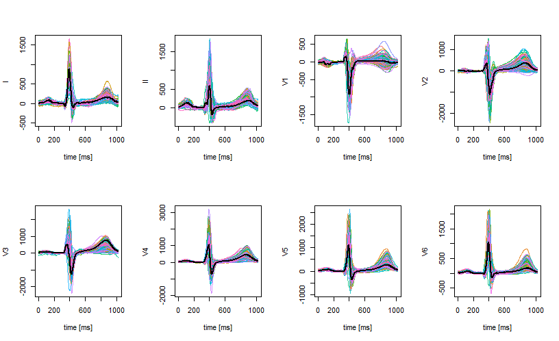

Figure 5: Plot of healthy data with superimposed the multivariate functional median computed maximizing the multivariate MBD @ref(eq:MBdefmultiv) with uniform weights.

## Correlation coefficient

When dealing with multivariate functional data, it is possible to compute correlation coefficients between observations’ univariate components that generalise the Spearman’s coefficient $\rho_s$, see (Valencia, Romo, and Lillo 2015b, 2015a). In particular, let us consider a set of bivariate ($L=2$) functional data $\{\mathbf{f_1},...,\mathbf{f_N}\}$. The Spearman coefficient related to the data set is defined by
$$\label{rho:spearman}
\hat{\rho_s} =
\hat{\rho_p}(MEI_{\{f_{11},...,f_{N1}\}}(\mathbf{f_1}),MEI_{\{f_{12},...,f_{N2}\}}(\mathbf{f_2})), (\#eq:rhospearman)$$
where $\hat{\rho_p}$ is the usual Pearson correlation coefficient between vectors and
$$MEI_{\{f_{11},...,f_{N1}\}}(\mathbf{f_1}) =
(MEI_{\{f_{11},...,f_{N1}\}}(f_{11}),...,MEI_{\{f_{11},...,f_{N1}\}}(f_{N1})),$$

$$MEI_{\{f_{12},...,f_{N2}\}}(\mathbf{f_2}) =
(MEI_{\{f_{12},...,f_{N2}\}}(f_{12}),...,MEI_{\{f_{12},...,f_{N2}\}}(f_{N2})).$$
Another definition can be obtained by replacing MEI by MHI. The properties of $\hat{\rho_s}$ are detailed in (Valencia, Romo, and Lillo 2015b), where also its consistency is proved.

The function `cor_spearman` can be used to compute the Spearman correlation coefficient @ref(eq:rhospearman) for a bivariate `mfData` object, using the ordering definition specified by `ordering` (the default is to use `MEI`) to rank univariate components and then compute the correlation coefficient. Besides `MEI`, also `MHI` can be used to determine ranks.

Another well known measure for concordance in bivariate data is the Kendall’s $\tau$ index. In (Valencia, Romo, and Lillo 2015a) the authors propose two generalizations of $\tau$ based on two different preorders between curves $\preceq$. Consider two functions $g$ and $h$ in $\mathcal{C}(I)$. Two possible preorders are:
$$\label{preordm}
g(t) \preceq_{m} h(t) \equiv \max_{t \in I} g(t) \leq \max_{t \in I}
h(t), (\#eq:preordm)$$

$$\label{preordi}
g(t) \preceq_{i} h(t) \equiv \int_I(h(t) -g(t)) dt \geq
0.(\#eq:preordi)$$
Let us consider a set of bivariate ($L=2$) functional data $\{\mathbf{f_1},...,\mathbf{f_N}\}$, then the functional $\hat{\tau}$ is
$$\label{tau:func}
\hat{\tau} = \binom{N}{2} \sum_{i<j}^{N} 2 \mathbb{I}(f_{i1}\preceq
f_{j1},f_{i2}\preceq f_{j2}) + 2 \mathbb{I}(f_{j1}\preceq
f_{i1},f_{j2}\preceq f_{i2}) -1. (\#eq:taufunc)$$
In fact it is possible to prove that $\hat{\tau}$ in @ref(eq:taufunc) measures the difference between the number of concordant pairs of curves and the number of discordant pairs of curves, using a possible preorder. The function `cor_kendall` can be used to compute the Kendall correlation coefficient @ref(eq:taufunc) for a bivariate `mfData` object, using the ordering definition specified by `ordering` (by default `max` is used, i.e., formula @ref(eq:preordm)) to rank univariate components, then to compute concordant and discordant pairs and then the correlation coefficient. Also `area` (i.e., formula @ref(eq:preordi)) can be used. As an example let us compute $\hat{\rho}$ and $\hat{\tau}$ on the simulated dataset (named `mfD`) shown in Figure 4:

```r
    cor_spearman(mfD, ordering ="MEI")
    [1] 0.6098597

    cor_kendall(mfD, ordering="area")
    [1] 0.4222222
```